# R Notebook

## Introduction

This dataset is originally from the National Institute of Diabetes and Digestive and Kidney Diseases. The objective is to predict based on diagnostic measurements whether a patient has diabetes.

## Data Dictionary

Several constraints were placed on the selection of these instances from a larger database. In particular, all patients here are females at least 21 years old of Pima Indian heritage.

- Pregnancies: Number of times pregnant
- Glucose: Plasma glucose concentration a 2 hours in an oral glucose tolerance test
- BloodPressure: Diastolic blood pressure (mm Hg)
- SkinThickness: Triceps skin fold thickness (mm)
- Insulin: 2-Hour serum insulin (mu U/ml)
- BMI: Body mass index (weight in kg/(height in m)^2)
- DiabetesPedigreeFunction: Diabetes pedigree function. Indicates the function which scores likelihood of diabetes based on family history
- Age: Age (years)
- Outcome: Class variable (0 or 1). If patient had diabetes 1 = Yes, 0 = No.

## Understand the data

The data was imported into R and run head to visualize the first 6 rows

```
##   Pregnancies Glucose BloodPressure SkinThickness Insulin  BMI
## 1           6     148            72            35       0 33.6
## 2           1      85            66            29       0 26.6
## 3           8     183            64             0       0 23.3
## 4           1      89            66            23      94 28.1
## 5           0     137            40            35     168 43.1
## 6           5     116            74             0       0 25.6
##   DiabetesPedigreeFunction Age Outcome
## 1                    0.627  50       1
## 2                    0.351  31       0
## 3                    0.672  32       1
## 4                    0.167  21       0
## 5                    2.288  33       1
## 6                    0.201  30       0
```

```
##   Pregnancies        Glucose      BloodPressure    SkinThickness
##  Min.   : 0.000   Min.   :  0.0   Min.   :  0.00   Min.   : 0.00
##  1st Qu.: 1.000   1st Qu.: 99.0   1st Qu.: 62.00   1st Qu.: 0.00
##  Median : 3.000   Median :117.0   Median : 72.00   Median :23.00
##  Mean   : 3.845   Mean   :120.9   Mean   : 69.11   Mean   :20.54
##  3rd Qu.: 6.000   3rd Qu.:140.2   3rd Qu.: 80.00   3rd Qu.:32.00
##  Max.   :17.000   Max.   :199.0   Max.   :122.00   Max.   :99.00
##     Insulin           BMI        DiabetesPedigreeFunction      Age
##  Min.   :  0.0   Min.   : 0.00   Min.   :0.0780           Min.   :21.00
##  1st Qu.:  0.0   1st Qu.:27.30   1st Qu.:0.2437           1st Qu.:24.00
##  Median : 30.5   Median :32.00   Median :0.3725           Median :29.00
##  Mean   : 79.8   Mean   :31.99   Mean   :0.4719           Mean   :33.24
##  3rd Qu.:127.2   3rd Qu.:36.60   3rd Qu.:0.6262           3rd Qu.:41.00
##  Max.   :846.0   Max.   :67.10   Max.   :2.4200           Max.   :81.00
##     Outcome
##  Min.   :0.000
##  1st Qu.:0.000
##  Median :0.000
##  Mean   :0.349
##  3rd Qu.:1.000
##  Max.   :1.000
```

Also looked at the dimensions of the data. The dataset had 768 rows and 9 columns

```r
dim(diabetes)
```

```
## [1] 768   9
```

```r
colnames(diabetes)
```

```
## [1] "Pregnancies"              "Glucose"
## [3] "BloodPressure"            "SkinThickness"
## [5] "Insulin"                  "BMI"
## [7] "DiabetesPedigreeFunction" "Age"
## [9] "Outcome"
```

Looking if we had any null values in the data or any duplicated values. No null values were present.

```
## $Pregnancies
## [1] 0
##
## $Glucose
## [1] 0
##
## $BloodPressure
## [1] 0
##
## $SkinThickness
## [1] 0
##
## $Insulin
## [1] 0
##
## $BMI
## [1] 0
##
## $DiabetesPedigreeFunction
## [1] 0
##
## $Age
## [1] 0
##
## $Outcome
## [1] 0
```

```
## [1] 0
```

Since We cannot have Bps, BMI, Skin Thickness and Glucose being zero(0) all zero values were replaced with the mean/median since dropping them would change the data.

```
##   Pregnancies        Glucose       BloodPressure    SkinThickness
##  Min.   : 0.000   Min.   : 44.00   Min.   : 24.00   Min.   : 7.00
##  1st Qu.: 1.000   1st Qu.: 99.75   1st Qu.: 64.00   1st Qu.:20.54
##  Median : 3.000   Median :117.00   Median : 72.00   Median :23.00
##  Mean   : 3.845   Mean   :121.68   Mean   : 72.25   Mean   :26.61
##  3rd Qu.: 6.000   3rd Qu.:140.25   3rd Qu.: 80.00   3rd Qu.:32.00
##  Max.   :17.000   Max.   :199.00   Max.   :122.00   Max.   :99.00
##     Insulin            BMI        DiabetesPedigreeFunction      Age
##  Min.   : 14.00   Min.   :18.20   Min.   :0.0780           Min.   :21.00
##  1st Qu.: 30.50   1st Qu.:27.50   1st Qu.:0.2437           1st Qu.:24.00
##  Median : 31.25   Median :32.00   Median :0.3725           Median :29.00
##  Mean   : 94.65   Mean   :32.45   Mean   :0.4719           Mean   :33.24
##  3rd Qu.:127.25   3rd Qu.:36.60   3rd Qu.:0.6262           3rd Qu.:41.00
##  Max.   :846.00   Max.   :67.10   Max.   :2.4200           Max.   :81.00
##     Outcome        age_cat
##  Min.   :0.000   Length:768
##  1st Qu.:0.000   Class :character
##  Median :0.000   Mode  :character
##  Mean   :0.349
##  3rd Qu.:1.000
##  Max.   :1.000
```

## Insights

### How was the population spread?

| age_cat | Percent |  |  |  |
| --- | --- | --- | --- | --- |
| Below_30 | 51.56 |  |  |  |
| 30s | 21.48 |  |  |  |
| 40s | 15.36 |  |  |  |
| 50s | 7.42 |  |  |  |
| 60s | 3.78 |  |  |  |
| Above_70 | 0.39 |  |  |  |

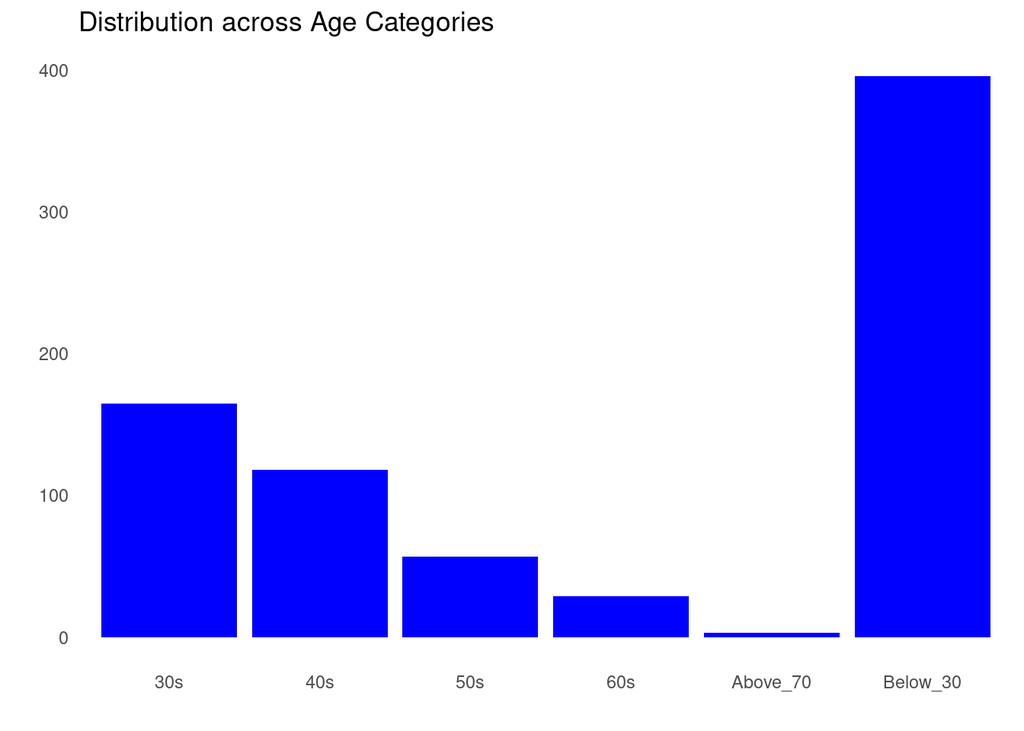

### Number of Pregnancies

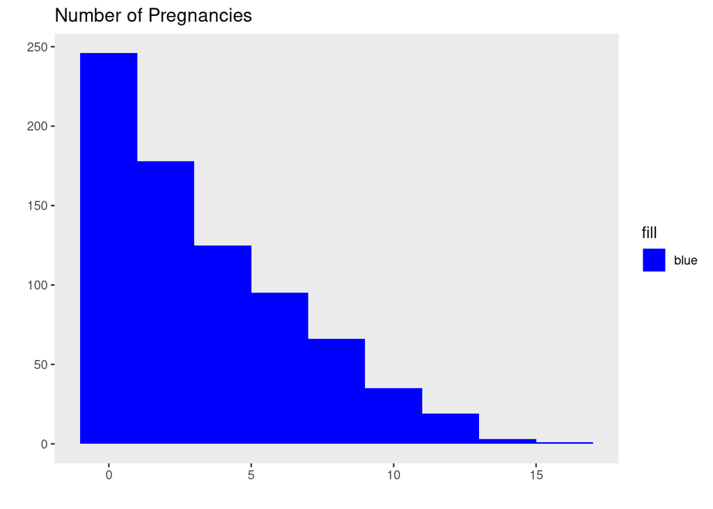

### Comparison of pregnancies and outcome

Those who had higher number of pregnancies had a higher chance of being diabetic.

[figure not shown]

### BMI numbers

About 61.98 % of the population had a BMI of above 30 which is considered as being obese. 1.04% had a BMI of above 50 which even though possible could be an outlier. 0.52% percent of the population were underweight with a BMI < 18.5

```
## # A tibble: 9 × 2
##   BMI_cat           Percent
##   <chr>               <int>
## 1 Moderate Obese        235
## 2 Obese                 179
## 3 Severe Obese          150
## 4 Normal                102
## 5 Very severe Obese      62
## 6 Morbid Obese           27
## 7 Super Obese             8
## 8 Underweight             4
## 9 Hyper obese             1
```

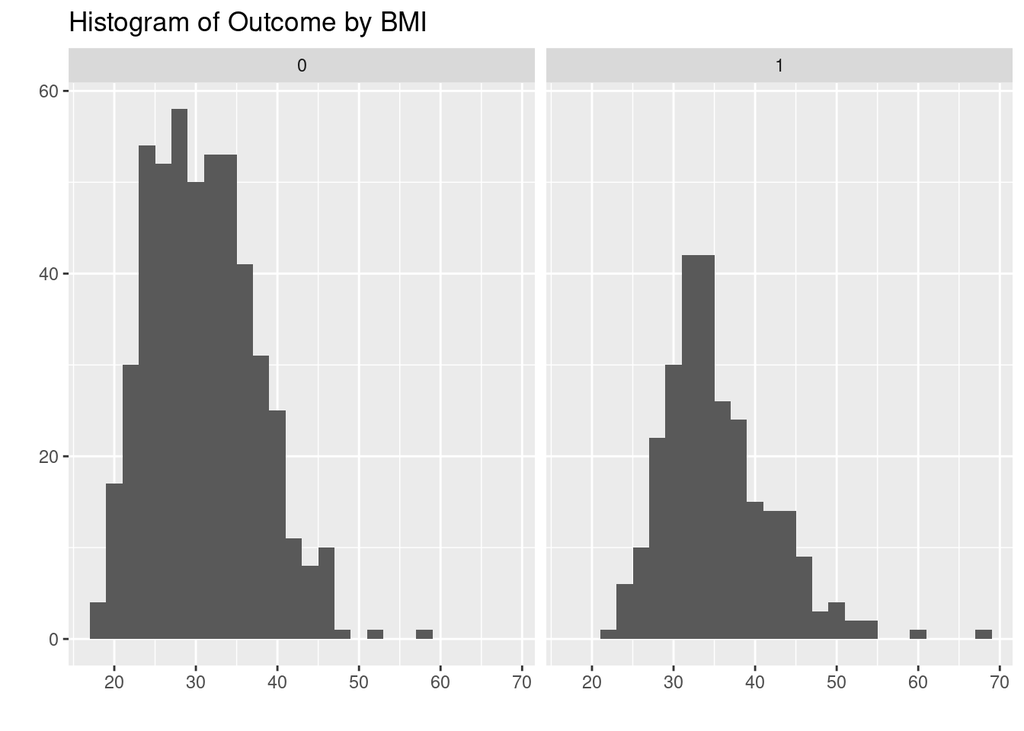

### Diabetes pedigree Function and BMI

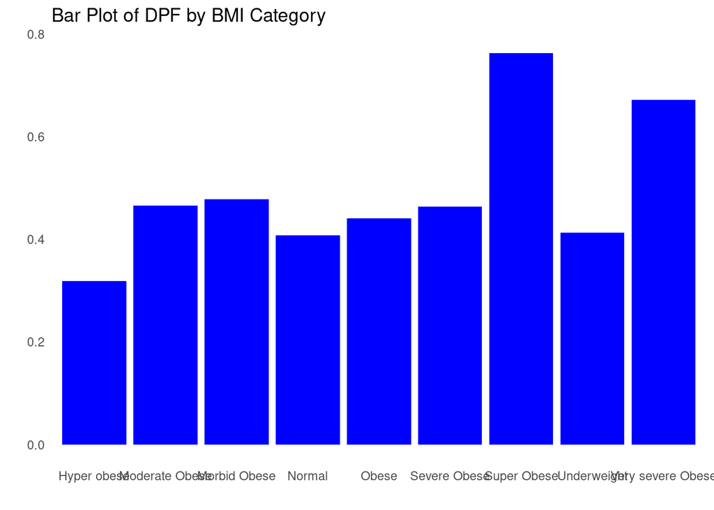

### Glucose ranges

Those with Glucose above 125 classified as hypergylcemia accounted for 40.49 %, Impaired glucose had 34.5% while the hypoglycemia accounted for 1%

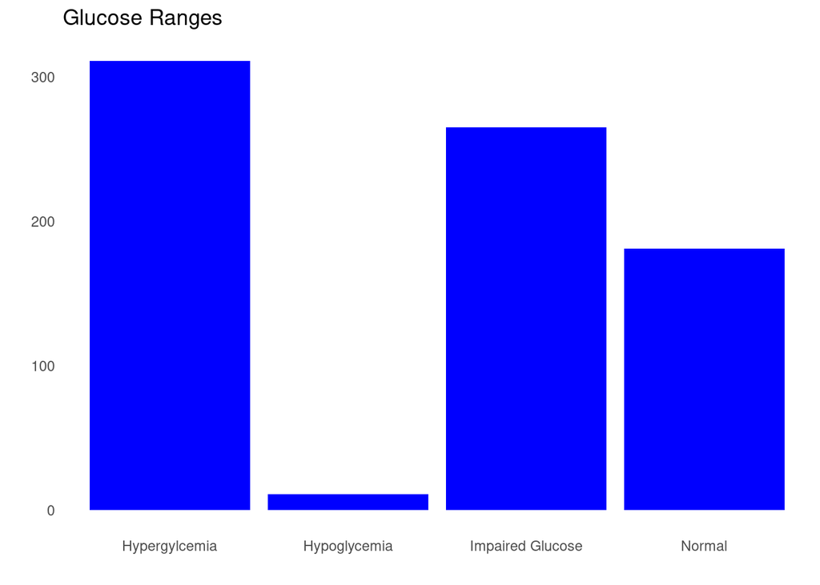

### Glucose Ranges and Diabetes Pedigree Function

Both the hyperglycemia and impaired glucose had the highest diabetes pedigree function.

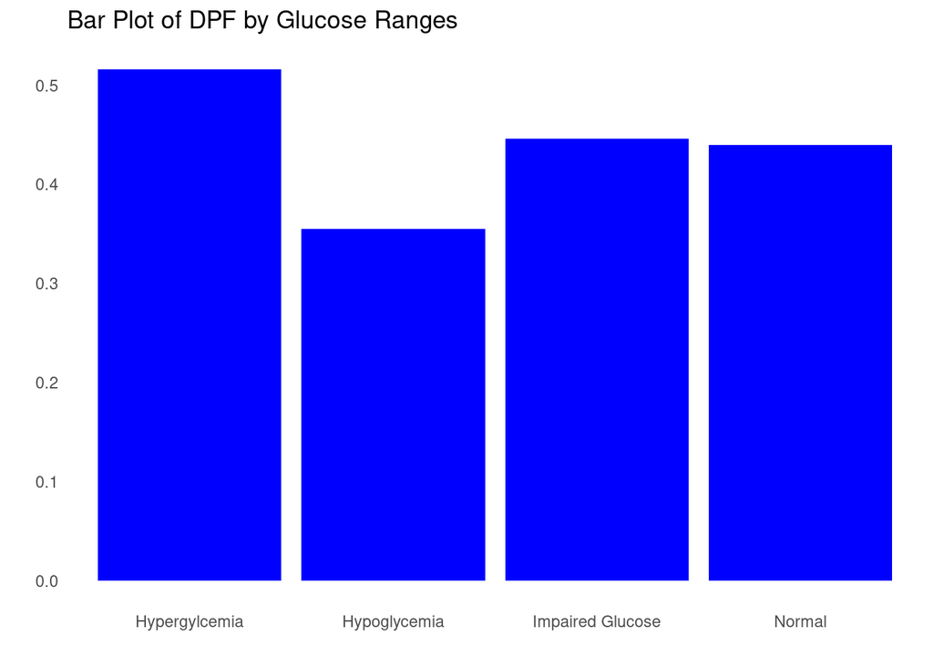

The patient with hyperglycemia or high glucose 2 hours after Oral glucose test had a higher chance of having diabetes as their outcome. Compared to the hypoglycemic who none had diabetes as the outcome.

[figure not shown]

### How do the various paramaters relate to each other

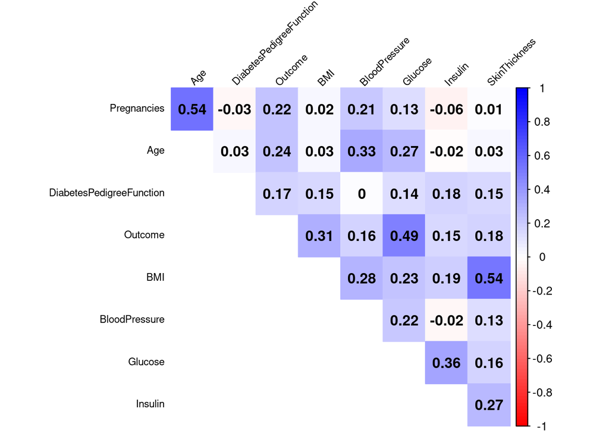

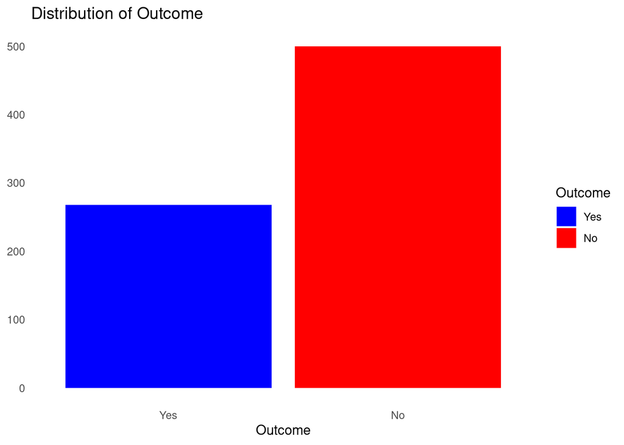

## comparison of age and outcome

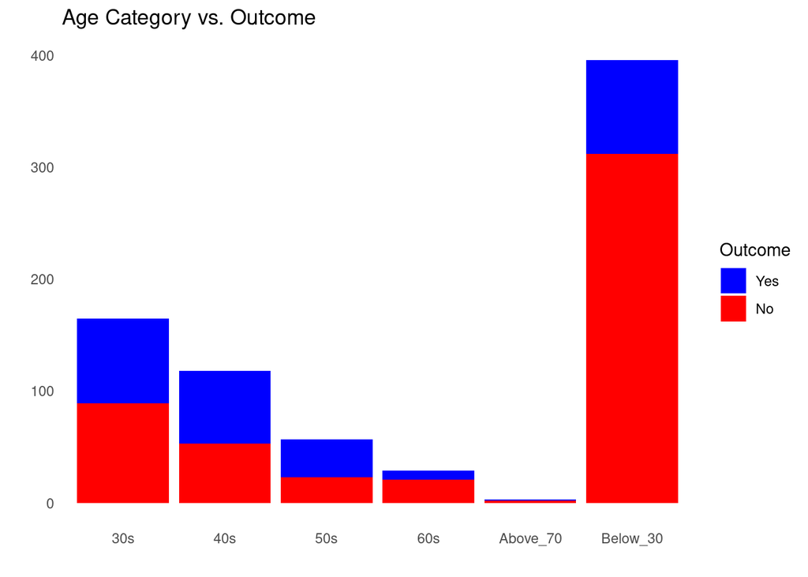

### Blood Pressure comparison

The study utilized Diastolic blood pressures that ranges from 60 - 80 mmHg. The BPs had a normal distribution though 11.2 % had low diastolic BP(less than 60mmHg). 62 % had normal BPs and 0.13% or 1 person had a Hypertensive crises BP > 120 .

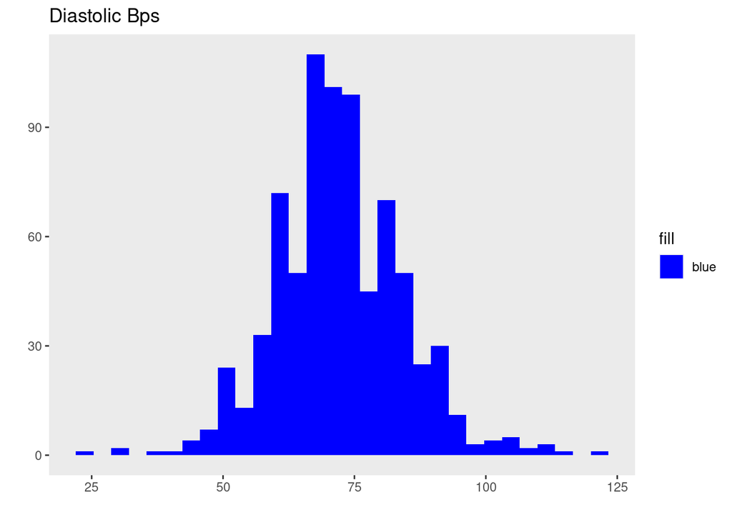

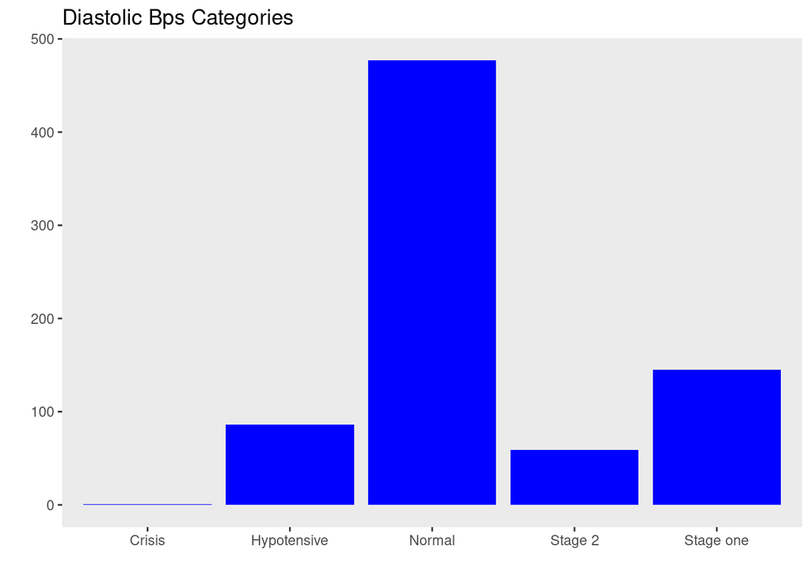

Diastolic blood pressure did not have such high impact on the outcome for diabetes.

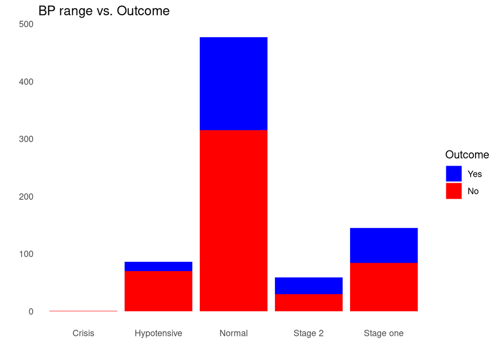

## Recommendation

Since more than 60% of the population were obese education and lifestyle modification measures should introduced to the community.

More screening measures should be introduced.